# White Wine: Analyzing the Variables by Ryan Heerwagen

### Investigating assorted other variables

Moving past alcohol, there are other variables that may be worth investigating.

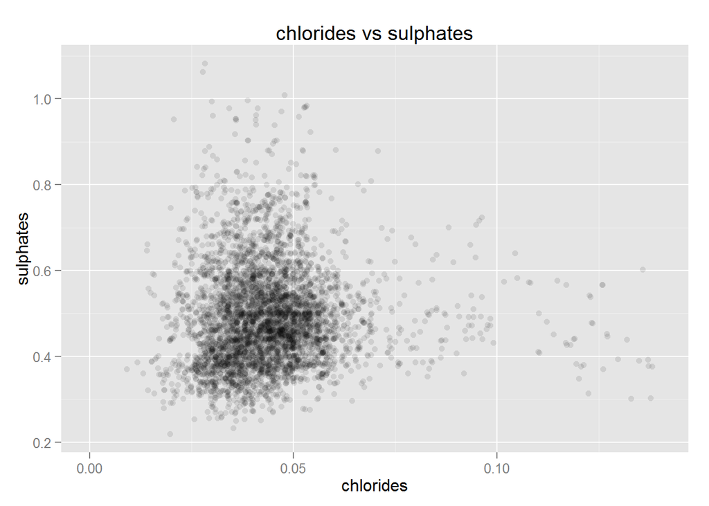

```
##
##  Pearson's product-moment correlation
##
## data:  whitwine$sulphates and whitwine$chlorides
## t = 1.1731, df = 4896, p-value = 0.2408
## alternative hypothesis: true correlation is not equal to 0
## 95 percent confidence interval:
##  -0.01124885  0.04474833
## sample estimates:
##        cor
## 0.01676288
```

I cannot find a relationship between chlorides and sulphates.

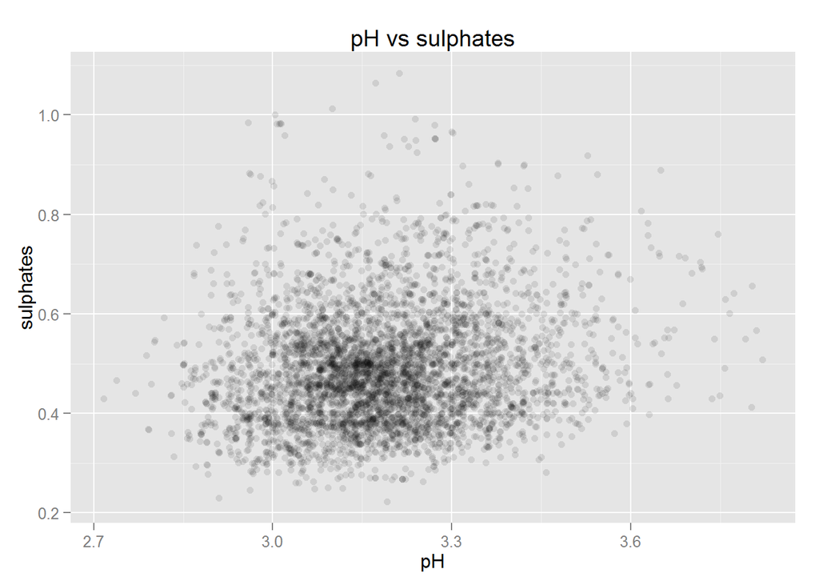

```
##
##  Pearson's product-moment correlation
##
## data:  whitwine$pH and whitwine$sulphates
## t = 11.047, df = 4896, p-value < 2.2e-16
## alternative hypothesis: true correlation is not equal to 0
## 95 percent confidence interval:
##  0.1285063 0.1831580
## sample estimates:
##       cor
## 0.1559515
```

From the data, there is a minor positive correlation between sulphates and pH, but it is still not one that could be easily detected from looking at a chart.

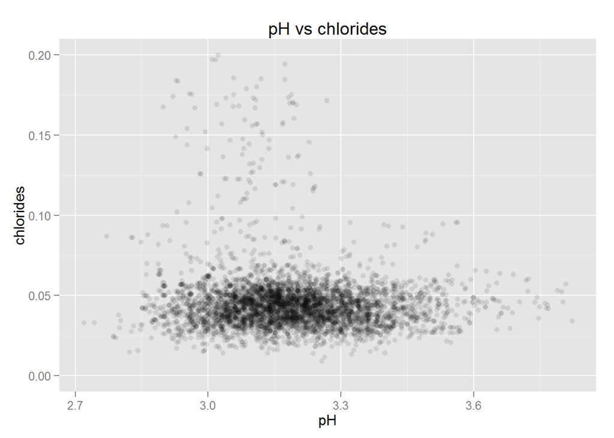

```
##
##  Pearson's product-moment correlation
##
## data:  whitwine$chlorides and whitwine$pH
## t = -6.3542, df = 4896, p-value = 2.285e-10
## alternative hypothesis: true correlation is not equal to 0
## 95 percent confidence interval:
##  -0.11814666 -0.06259154
## sample estimates:
##         cor
## -0.09043946
```

From the graph, there isn’t much to tell, however from the correlation test there may be a very minor correlation. I can’t see any patterns apparent from the plot itself.

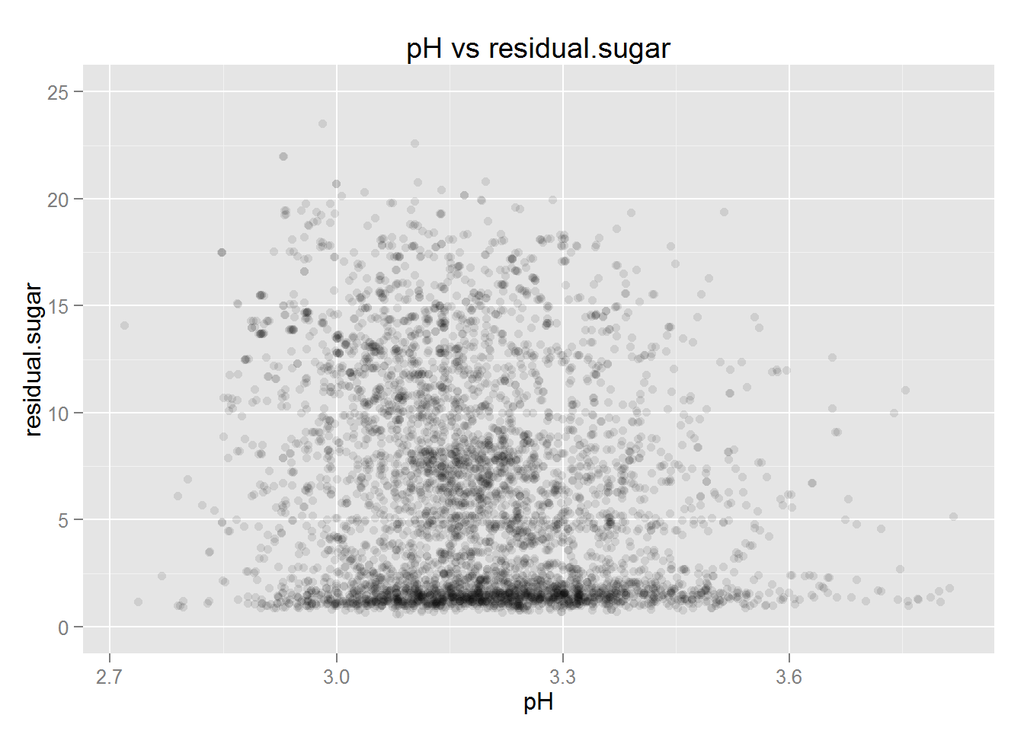

```
##
##  Pearson's product-moment correlation
##
## data:  whitwine$residual.sugar and whitwine$pH
## t = -13.847, df = 4896, p-value < 2.2e-16
## alternative hypothesis: true correlation is not equal to 0
## 95 percent confidence interval:
##  -0.2209387 -0.1670352
## sample estimates:
##        cor
## -0.1941335
```

There is some correlation between residual sugar and pH, although it is best perceived in the reduction of very high values of residual sugar as pH rises. It still isn’t large.

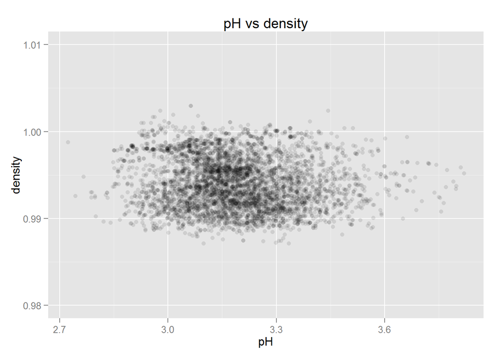

```
##
##  Pearson's product-moment correlation
##
## data:  whitwine$density and whitwine$pH
## t = -6.5776, df = 4896, p-value = 5.281e-11
## alternative hypothesis: true correlation is not equal to 0
## 95 percent confidence interval:
##  -0.1212801 -0.0657574
## sample estimates:
##         cor
## -0.09359149
```

There is a small correlation between pH and density. The plot doesn’t give much additional information.

As notable from earlier plots, alcohol and density negatively correlate to a very high degree. This can confuse the earlier result showing a negative correlation between quality and density, because if quality negatively correlates with density, and positively correlates with alcohol, then if alcohol also negatively correlates with density, then the alcohol-density correlation may explain the quality-density correlation.

### Looking into sugar

Let’s take a closer look at sugar. Because sugar was a matter of curiosity earlier, I intend to create a new variable based upon the absolute value of a sugar observation from the mean, in case the real issue involves extreme values of sugar in one way or another.

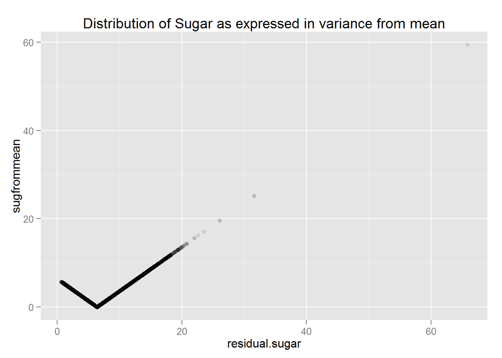

This plot is not necessary, but it does help capture the distribution of sugar, and highlights that there are many outliers, and a wider distribution over the mean than under it.

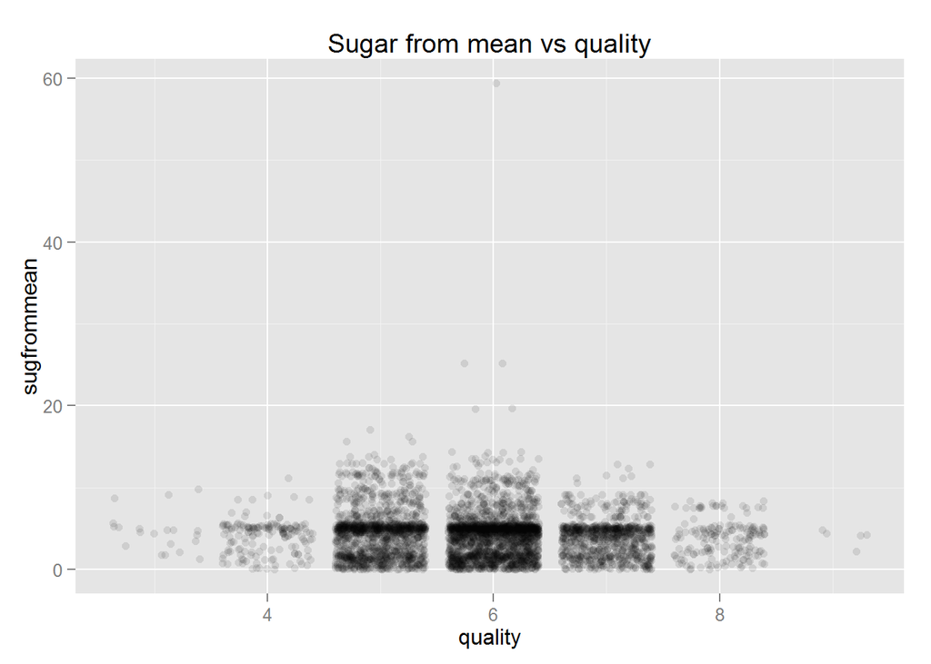

```
##
##  Pearson's product-moment correlation
##
## data:  whitwine$quality and whitwine$sugfrommean
## t = -5.0069, df = 4896, p-value = 5.726e-07
## alternative hypothesis: true correlation is not equal to 0
## 95 percent confidence interval:
##  -0.09918166 -0.04345386
## sample estimates:
##         cor
## -0.07137346
```

Checking the residual sugar value degree of distance from the mean doesn’t find much of a correlation. There’s a very small one, which might suggest that people don’t like the extremes, but this might not be the most helpful piece of the puzzle due to the size.

Let’s just check the distributions of our sugar variables again for comparison.

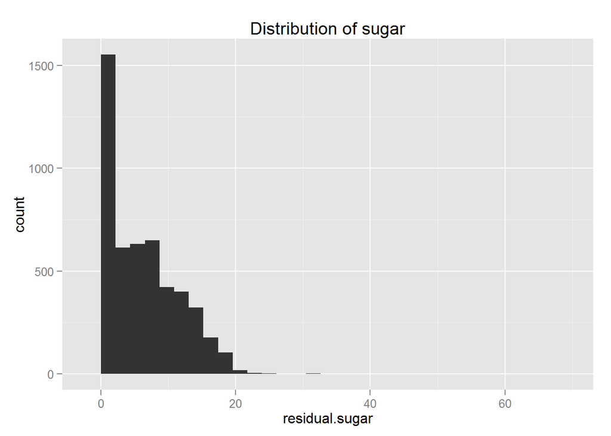

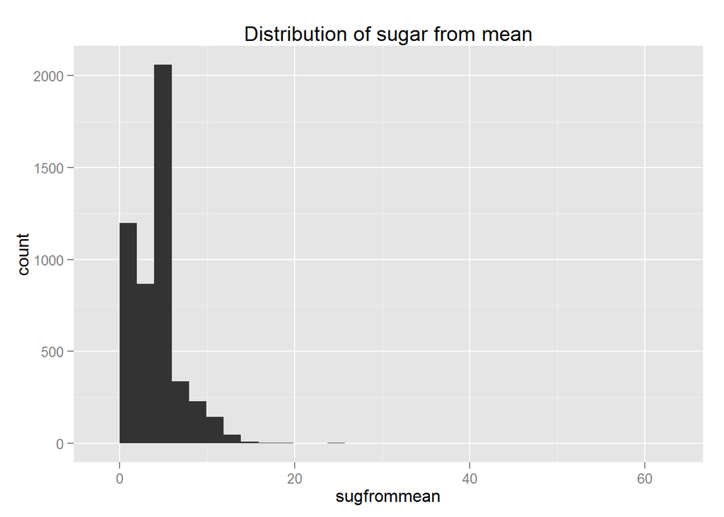

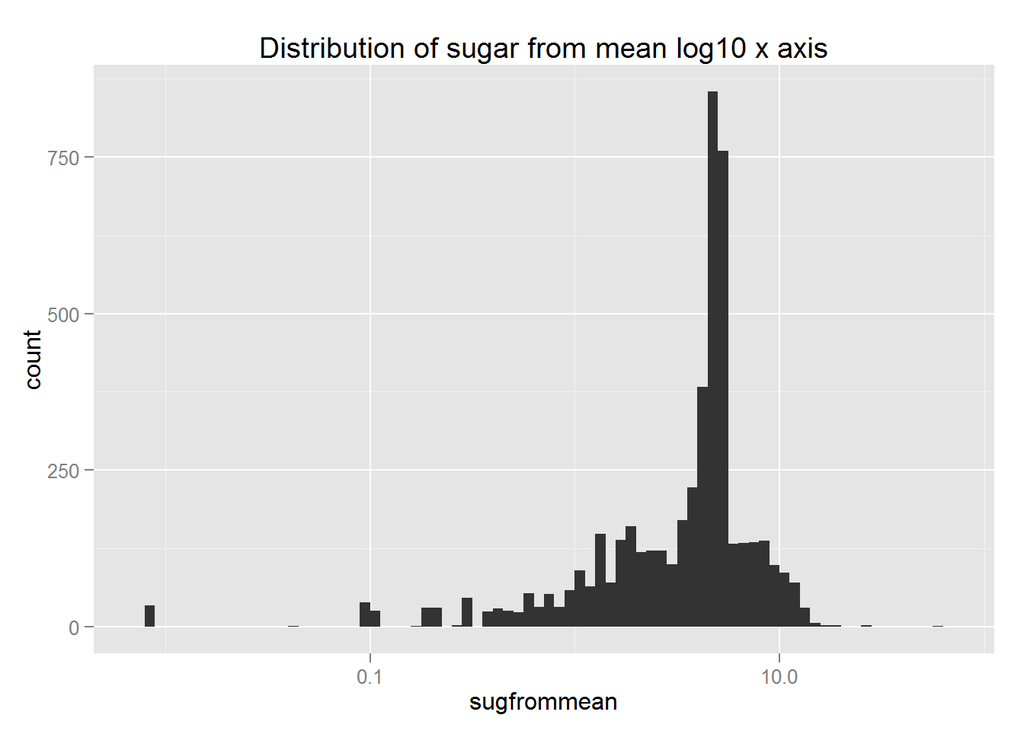

Sugar suffers from a limit to how much residual which can remain, which skews the distribution. There’s a glut of near zero amounts. I do not think sugar was as fruitful as some of the other information has been.

### Looking into bound sulfur dioxide

Now to follow up on an earlier curiosity, let’s isolate out bound sulfur dioxide and making the comparisons. Given that in our data set bound sulfur dioxide is just the total sulfur dioxide - free sulfure dioxide, this should be easy to generate.

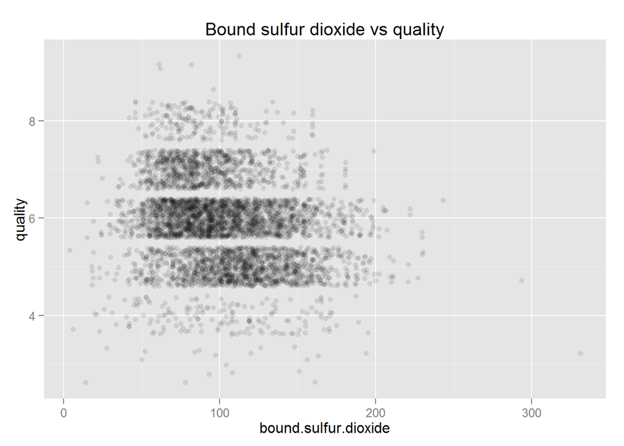

```
##
##  Pearson's product-moment correlation
##
## data:  whitwine$quality and whitwine$bound.sulfur.dioxide
## t = -15.62, df = 4896, p-value < 2.2e-16
## alternative hypothesis: true correlation is not equal to 0
## 95 percent confidence interval:
##  -0.2443831 -0.1910269
## sample estimates:
##        cor
## -0.2178678
```

Bound sulfur dioxide has a noted negative relationship between it and quality. It is still a low enough correlation where it can be hard to tell from a plot, but the estimated correlation appears larger than the one detected for total sulfur dioxide.

Now, because both variables impact quality, let’s investigate alcohol vs bound sulfur dioxide.

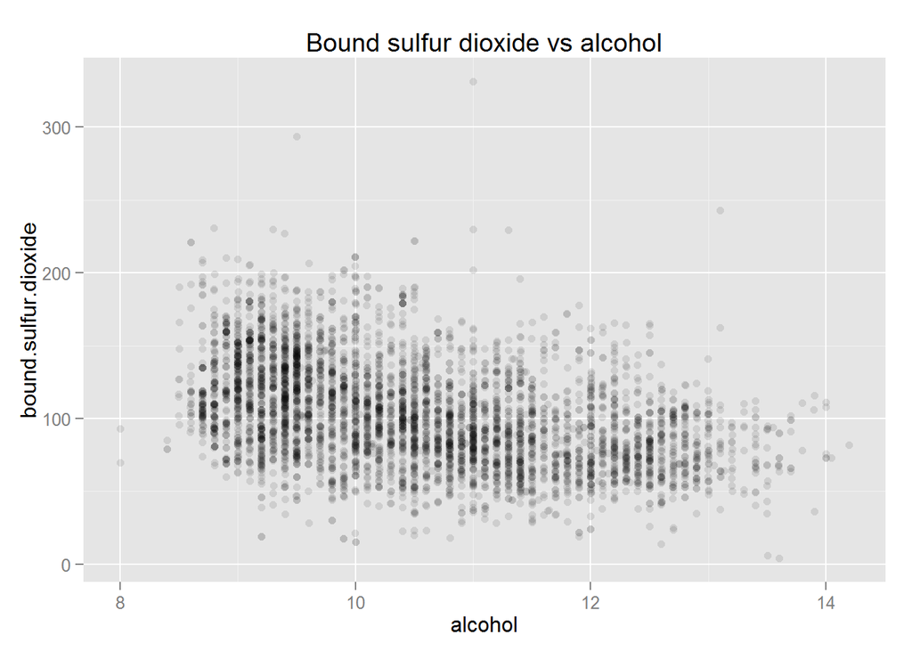

```
##
##  Pearson's product-moment correlation
##
## data:  whitwine$alcohol and whitwine$bound.sulfur.dioxide
## t = -33.034, df = 4896, p-value < 2.2e-16
## alternative hypothesis: true correlation is not equal to 0
## 95 percent confidence interval:
##  -0.4495544 -0.4037440
## sample estimates:
##       cor
## -0.426923
```

Bound sulfur dioxide and alcohol also have a very negative relationship, making one wonder how much of the relationship between quality and sulfur dioxide is explained by alcohol/vice versa. It can actually be detected from a plot.

### Fixed and volatile acidity comparison

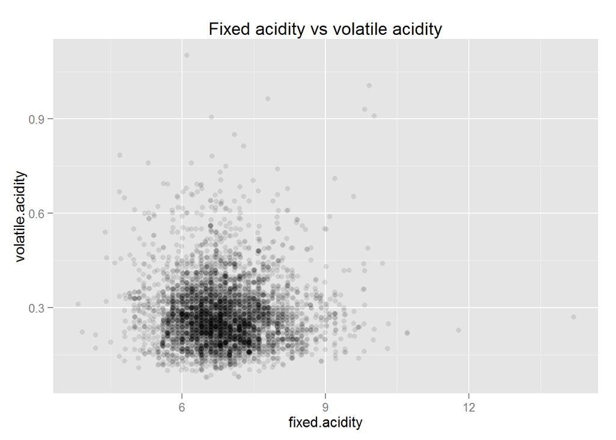

```
##
##  Pearson's product-moment correlation
##
## data:  whitwine$fixed.acidity and whitwine$volatile.acidity
## t = -1.5886, df = 4896, p-value = 0.1122
## alternative hypothesis: true correlation is not equal to 0
## 95 percent confidence interval:
##  -0.050671536  0.005312543
## sample estimates:
##         cor
## -0.02269729
```

Fixed and volatile acidity do not seem to have any relationship.

### Correlation Plot

Also, just to see if anything hasn’t been found, here’s an overview of the entire set of correlations:

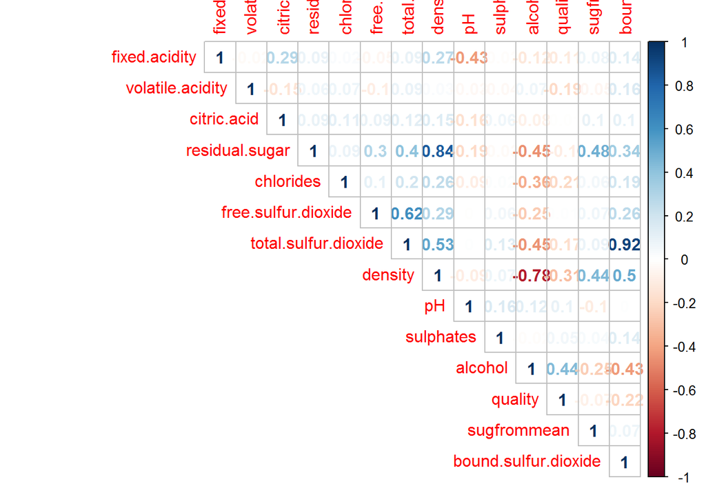

The correlation plot displays a lot of potentially fruitful relationships between variables.

### Alcohol vs quality boxplot

Additionally, given that we know alcohol is one of the stronger relationships in existence vs quality, let’s create a boxplot to give a better picture of the variation of the amount of alcohol for each quality rating.

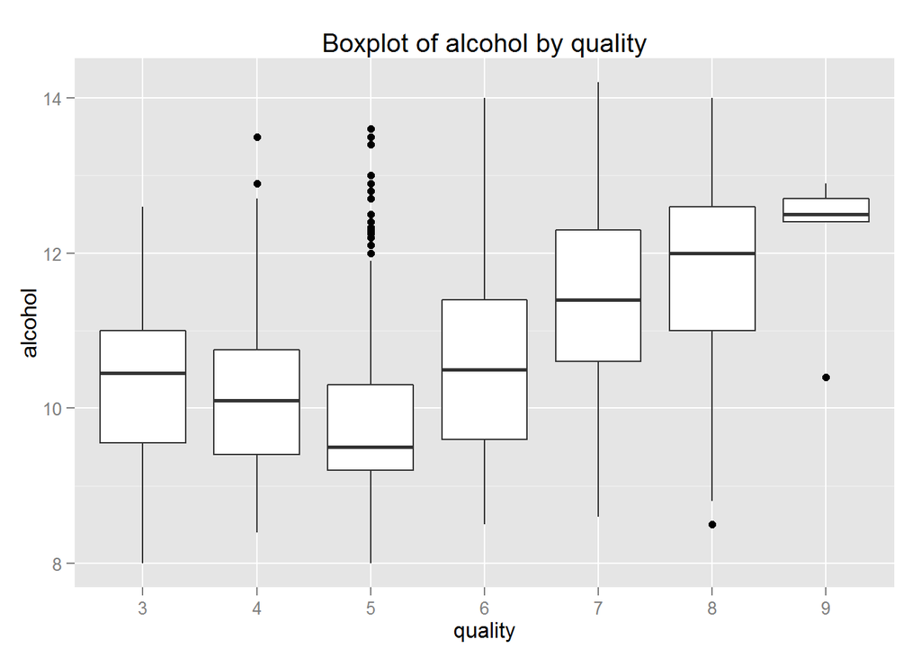

Interestingly, it looks like average alcohol dips until it reaches the rating factor of 5, and then it starts to increase as quality increases.

# Bivariate Analysis

### Talk about some of the relationships you observed in this part of the investigation. How did the feature(s) of interest vary with other features in the dataset?

I noticed that alcohol, bound sulfur dioxide, and density all varied with quality.

### Did you observe any interesting relationships between the other features (not the main feature(s) of interest)?

I noticed that alcohol, bound sulfur dioxide, and density all tended to have relations among each other that could make the causal relations complicated to separate out. Also, the relationship between residual.sugar and density is rather substantial, being an even stronger relation.

Additionally, the relationship between alcohol and quality seems to not really be linear given a boxplot on the data.

### What was the strongest relationship you found?

The strongest relationship is the positive correlation between density and residual sugar.

# Multivariate Plots Section

Testing the relationships between a few categorizations and quality. As a general rule, I will round variables to smooth out the data I am working with.

### Classifications by alcohol content

One categorization I will make is an alcohol.bucket variable based upon external knowledge about wine classifications by alcohol content. The source was listed earlier: http://www.realsimple.com/holidays-entertaining/entertaining/food-drink/alcohol-content-wine

One test I will do given my earlier curiosity on the relationship between residual sugar and quality, is that given the alcohol categories found elsewhere online, I will plot the quality vs residual sugar for the different alcohol classifications.

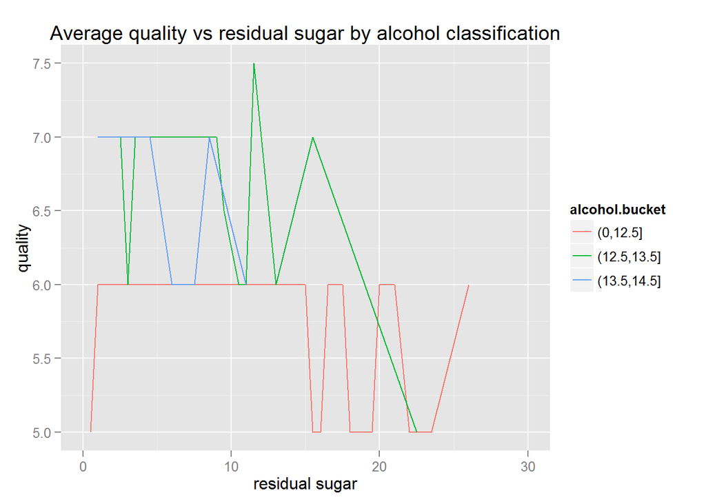

I’m hesitant to draw conclusions from this graph. The relationship of residual sugar and quality past 15 may be of interest, but given the data this could just be noise.

Because this alcohol break-down is a new curiosity for me, and one that existing writings led me to expect might be of importance, I will test a few other variables against it.

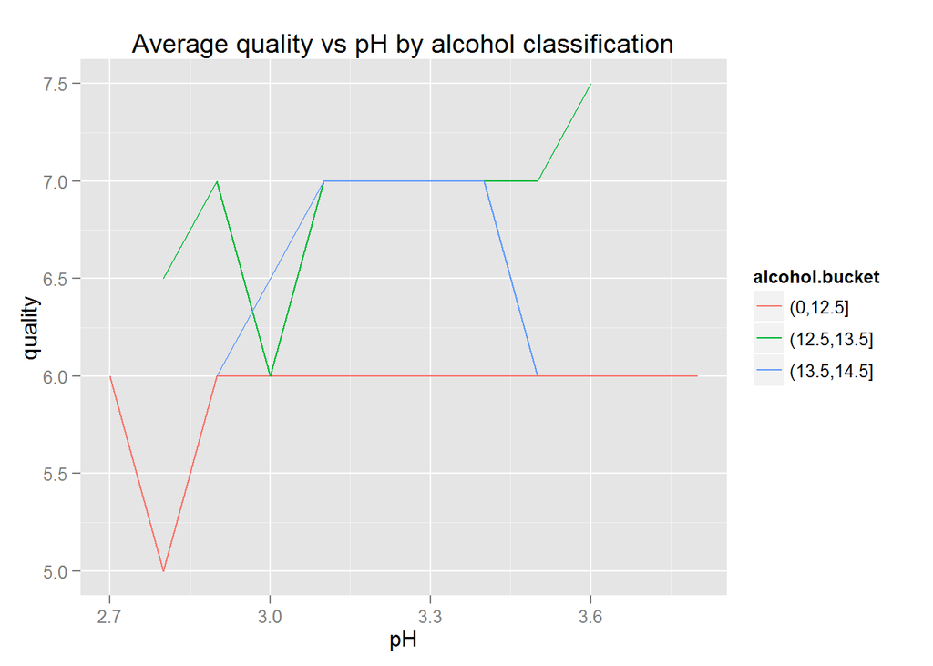

This data still does not lead me to any conclusions I find particularly interesting.

[figure not shown]

Lastly for these tests testing out the relationship between residual sugar and density by alcohol level is interesting, but does mostly reveals that there is no difference in the relationship by alcohol level. While the graph is jagged, most of the lines are parallel.

### Classifications by quality

I will now also start using quality as a factor, so that way I can see if there are any complicated relationships involving it.

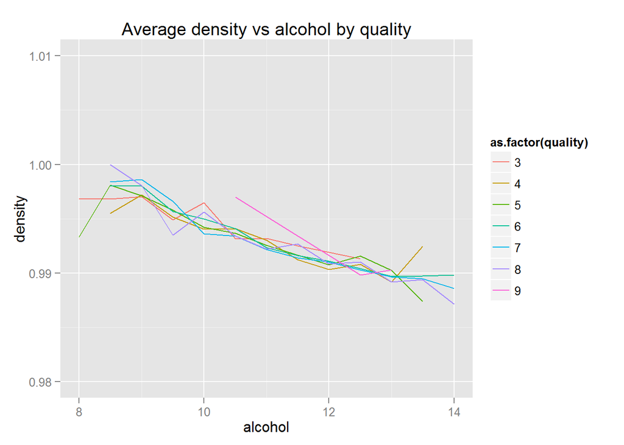

Looking at density, I don’t think variations in quality impact the relationship it has with alcohol. The most promising sign it might is the last data-point for quality 4 wines with alcohol levels around 13.5, however, I think that’s a result of low samples.

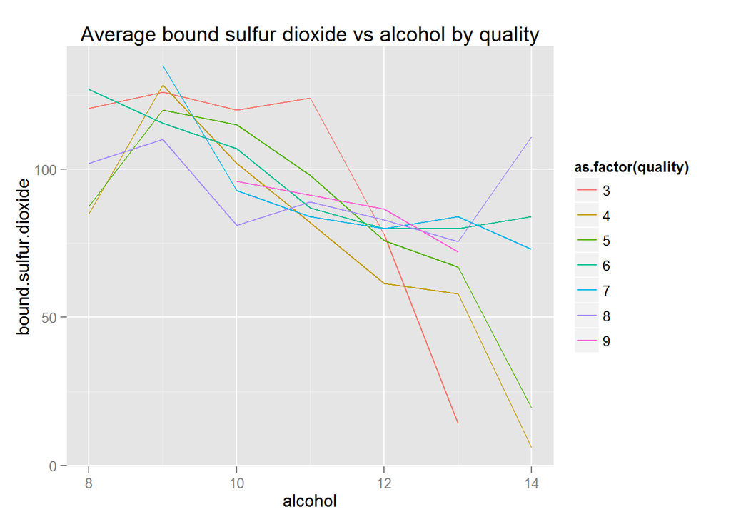

Looking at bound sulfur dioxide against alcohol by quality shows that there is a real divergence in the average bound sulfur dioxide by alcohol for each quality of wine. Lower quality wines show a higher decrease in bound sulfur dioxide as alcohol goes up, while higher quality wines seem not to, and level out much more.

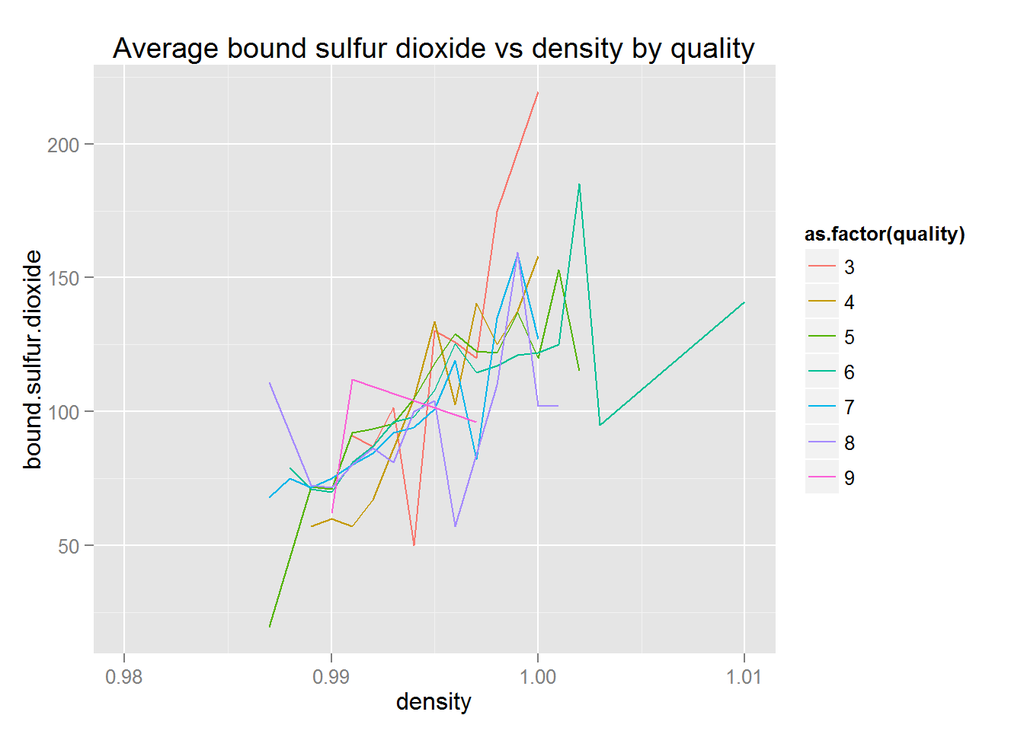

Moving on to test density vs bound sulfur dioxide, my impression is that the data is too noisy to pick out a useful trend. Not all qualities persist across all of the densities.

# Multivariate Analysis

### Talk about some of the relationships you observed in this part of the investigation. Were there features that strengthened each other in terms of looking at your feature(s) of interest?

As can be noted, the density does not seem to explain any of the variance of quality that alcohol does not already explain, as the two variables move hand-in-hand when explaining quality. The same seems likely true for bound sulfur dioxide and density.

Additionally, bound sulfur dioxide does, although in a more complicated manner, as while at the point of low levels of alcohol and high levels of sulfur dioxide the plots are relatively similar, higher quality wines tend to combine more bound sulfur dioxide with alcohol than low quality wines.

### Were there any interesting or surprising interactions between features?

I was relatively surprised at the relationship between alcohol, quality, and bound sulfur dioxide, where at lower quality levels there is a trade-off, if there is more alcohol there will be less bound sulfur dioxide, and this trade-off is reduced at higher levels of quality, as that relationship weakens at quality levels of 6 and up.

### OPTIONAL: Did you create any models with your dataset? Discuss the strengths and limitations of your model.

# Final Plots and Summary

### Plot One

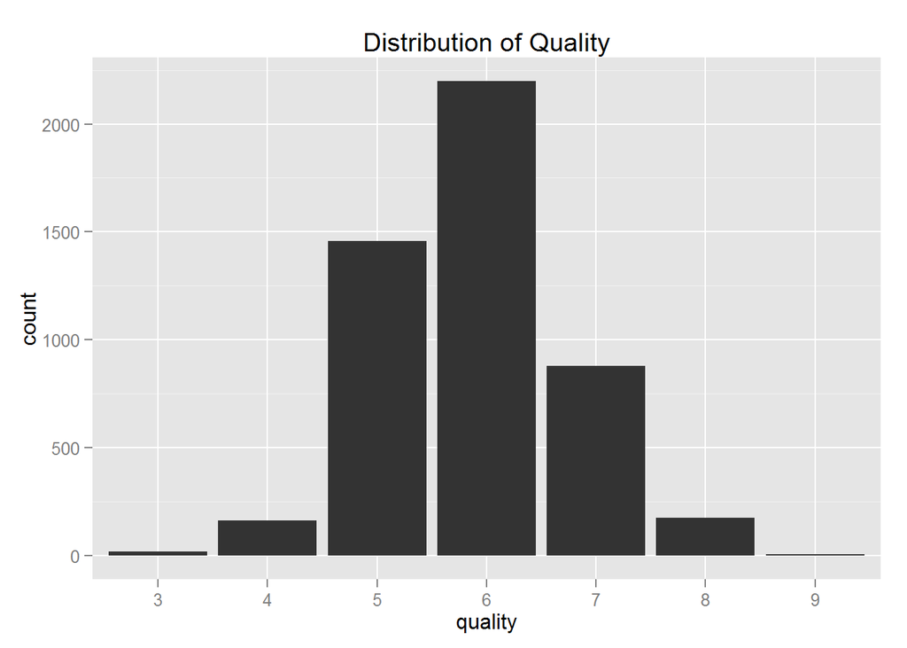

### Description One

The distribution of wine qualities is unimodal. There is some degree of skew, however, the data is relatively normal. Taking a summary of the data shows that the median is relatively close to the mean, however, the distribution still does not seem quite normal. Some of this issue may simply be due to the smaller set of discrete possibilities for factor

### Plot Two

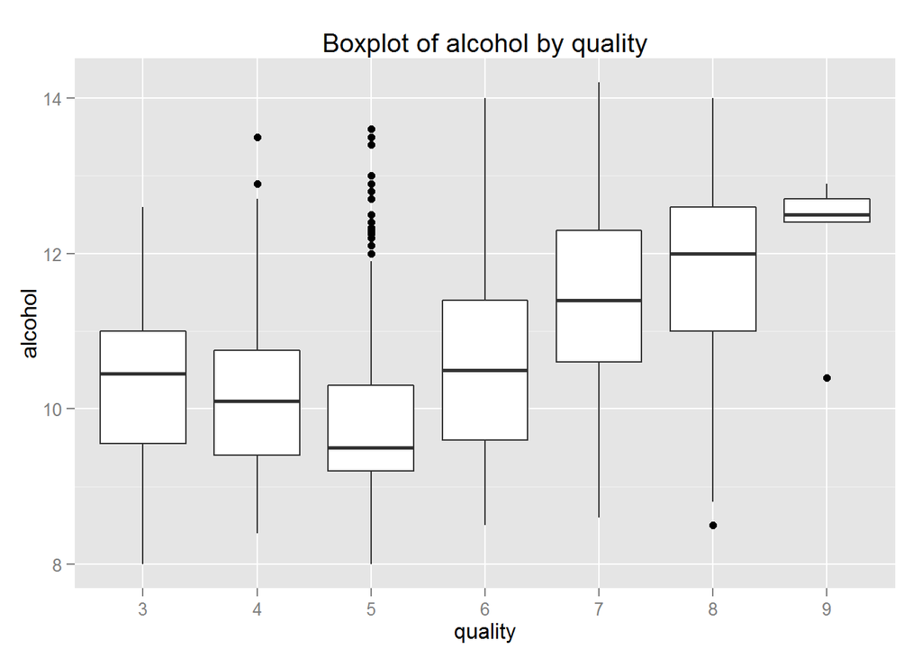

### Description Two

This chart is a boxplot. As noted before, it looks like average alcohol dips until it reaches the rating factor of 5, and then it starts to increase as quality increases. This suggests that the distribution of alcohol vs quality might have more of a U-shape than would originally be guessed by running the correlation.

### Plot Three

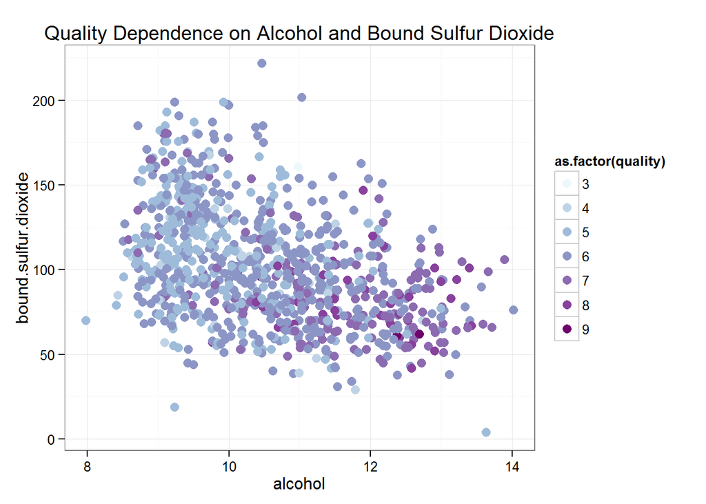

### Description Three

This plot shows what happens with the trade-off between alcohol and bound sulfur dioxide as quality increases. As can be noted there appears to be a negative correlation between quality and bound sulfur dioxide, but also has quality increases, the degree to which changes in sulfur dioxide matter appears to decline, as high alcohol, low quality drinks show larger shifts in bound sulfur dioxide than high quality drinks. This plot also shows the broad clusterings of quality in alcohol.

# Reflection

This dataset has 4898 observations of 12 variables from a 2009 study on white wines. When I first approached the data, I went for bulk scatterplots of variables against quality, to hopefully visually identify any stronger relationships. From each set of analyses I started checking related variables or ones I thought were especially interesting to see if I could learn more about what was going on there.

The big source of difficulty for me with dealing with this dataset is that most of the relationships between quality and other variables are somewhat low, as alcohol, the strongest correlating variable, only has a correlation of .44, and given that R^2 is the square of the correlation, this means that the strongest relationship only explains bit less than .2 of the variation. Testing on alcohol and other variables related to alcohol and quality did bear a lot of fruit though, and the relationship between bound sulfur dioxide and alcohol was very interesting.

I think that there’s a lot that I haven’t covered, the correlation plot shows a lot of relationships I didn’t explore in very much depth. I think this would be more interesting data though, if it had details like white wine type, year, price, location, as well as more high alcohol varieties of wine. My research shows that the very high alcohol category does not exist, and that even the high alcohol category has very low representation.